# hw-ch7

Austin Melendez

2026-04-02

Section 7.9: Exercises 3, 4, 5

```r
library(ISLR2)
```

## Exercise 3

We are given: $b_1(X) = X$ $b_2(X) = (X-1)^2 I(X\ge1)$

$\hat{\beta}_0 = 1$ $\hat{\beta}_1 = 1$ $\hat{\beta}_2 = -2$

Estimate curve between $X = -2$ and $X = 2$.

Our Model: $\hat{Y} = 1+[1\times X]-[2\times (X-1)^2 I(X\ge1)] + \epsilon$

Case 1 $X < 1$:
$$\hat{Y} = 1 + X$$

Case 2 $X \ge 1$:
$$\hat{Y} = 1 + X - 2(X-1)^2$$
Image summary: * From **−2** to **1** linear line increasing * Smooth transition at **1** * After **1** Concave-down parabola

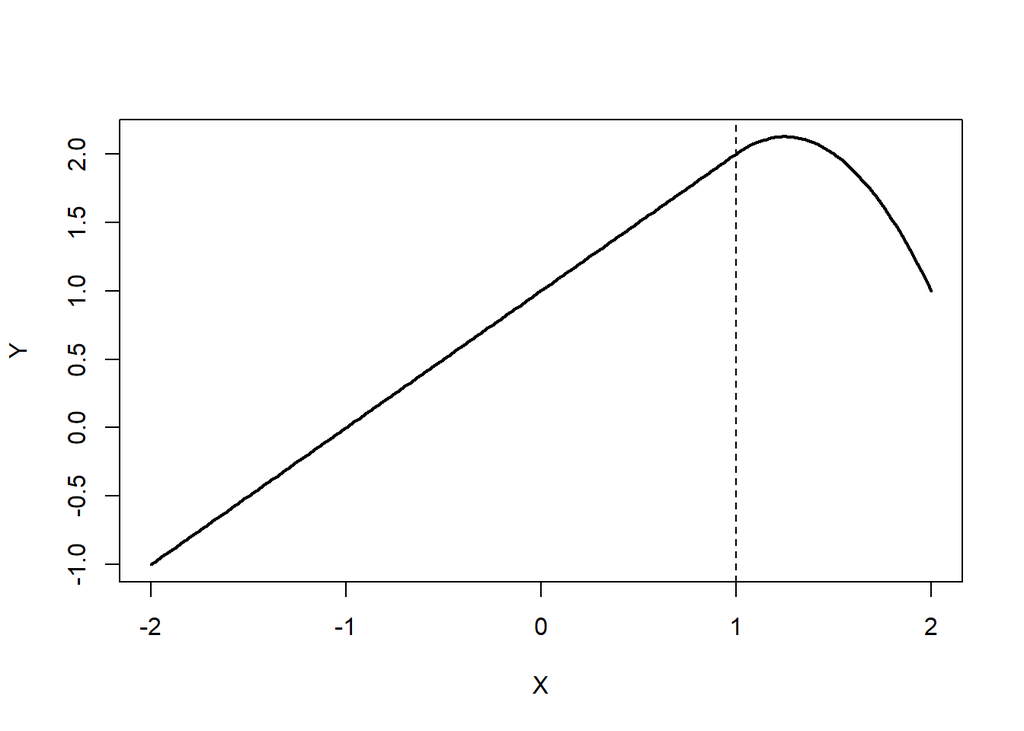

```r
x <- seq(-2, 2, length = 200)

y <- ifelse(x < 1,
            1 + x,
            1 + x - 2*(x - 1)^2)

plot(x, y, type = "l", lwd = 2,
     xlab = "X", ylab = "Y")
abline(v = 1, lty = 2)
```

## Exercise 4

We are given: $b_1(X) = I(0\le X\le 2)-(X-1) I(1\le X\le 2)$ $b_2(X) = (X-3) I(3\le X\le 4)+I(4<X<5)$

$\hat{\beta}_0 = 1$ $\hat{\beta}_1 = 1$ $\hat{\beta}_2 = 3$

Estimate curve between $X = -2$ and $X = 6$.

Model: $\hat{Y} = 1+[1\times I(0\le X\le 2)-(X-1) I(1\le X\le 2)]+[3\times (X-3) I(3\le X\le 4)+I(4<X<5)] + \epsilon$

Case 1 $X < 0$:
$$\hat{Y} = 1$$

Case 2 $0 \le X < 1$:
$$\hat{Y} = 2$$

Case 3 $1 \le X < 2$:
$$\hat{Y} = 3 - X$$

Case 4 $2 < X < 3$:
$$\hat{Y} = 1$$

Case 5 $3 \le X \le 4$:
$$\hat{Y} = 3X - 8$$

Case 6 $4 < X \le 5$:
$$\hat{Y} = 4$$

Case 7 $X > 5$:
$$\hat{Y} = 1$$

Image summary: * Flat at **1** (left tail) * Jump to **2** on [0,1) * Decreasing line to **1** on [1,2] * Flat again at **1** * Sharp increase on [3,4] * Flat at **4** on (4,5] * Drop back to **1**

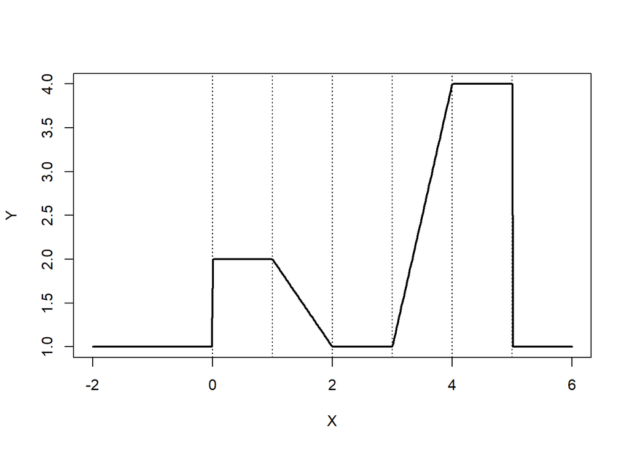

```r
x <- seq(-2, 6, length = 400)

y <- ifelse(x < 0, 1,
     ifelse(x < 1, 2,
     ifelse(x <= 2, 3 - x,
     ifelse(x < 3, 1,
     ifelse(x <= 4, 3*x - 8,
     ifelse(x <= 5, 4, 1))))))

plot(x, y, type = "l", lwd = 2,
     xlab = "X", ylab = "Y")

abline(v = c(0,1,2,3,4,5), lty = 3)
```

## Exercise 5

Consider two curves, $\hat{g}_1$ and $\hat{g}_2$, defined by:

$$\hat{g}_1 = arg\space
min(\sum^{n}_{i=1}(y_i - g(x_i))^2 + \lambda \int[g^{(3)}(x)]^2 \space
dx)$$

$$\hat{g}_2 = arg\space
min(\sum^{n}_{i=1}(y_i - g(x_i))^2 + \lambda \int[g^{(4)}(x)]^2 \space
dx)$$

where $g^{(m)}$ represents the mth derivative of g.

#### A

As $\lambda \to \infty$, will $\hat{g}_1$ or $\hat{g}_2$ have the smaller training RSS?

$\hat{g}_1$ penalizes 3rd derivative → quadratic (degree 2) $\hat{g}_2$ penalizes 4th derivative → cubic (degree 3)

Cubic is more flexible and fits training data better. So $\hat{g}_2$ has smaller training RSS.

#### B

As $\lambda \to \infty$, will $\hat{g}_1$ or $\hat{g}_2$ have the smaller test RSS?

Cubic has lower bias than quadratic and typically generalizes better. So $\hat{g}_2$ has smaller test RSS.

#### C

For $\lambda = 0$, will $\hat{g}_1$ or $\hat{g}_2$ have the smaller training and test RSS?

Training RSS = 0 for both meaning they both overfit, which results in high test RSS